# BUA 455 - Week 5: Cheat Sheets, Functions, and Review

Penelope Pooler Eisenbies

2024-02-12

```r
# this line specifies options for default options for all R Chunks
knitr::opts_chunk$set(echo=T,
                      highlight=T)

# suppress scientific notation
options(scipen=100)

# install helper package (pacman) if needed
if (!require("pacman")) install.packages("pacman", repos = "http://lib.stat.cmu.edu/R/CRAN/")
# install and load required packages
# pacman should be first package in parentheses and then list others
pacman::p_load(pacman, tidyverse, gridExtra, magrittr, lubridate,
               knitr, kableExtra)

# verify packages (comment out in finished documents)
p_loaded()
```

```
##  [1] "kableExtra" "knitr"      "magrittr"   "gridExtra"  "lubridate"
##  [6] "forcats"    "stringr"    "dplyr"      "purrr"      "readr"
## [11] "tidyr"      "tibble"     "ggplot2"    "tidyverse"  "pacman"
```

### Quiz 1 on Thursday 2/16

- Weeks 1 - 4 (Lectures 1 - 8)
  - Quiz questions will be similar (but not identical) to Practice Questions
  - Mix of R datasets and imported datasets
    - I will provide R code to import data
    - Quiz Template and data files will be provided in Zipped project
    - Review Practice Questions, HW assignments, and Demo Videos
    - **You will be required to download, unzip, and and save a project to your computer (not in Downloads), as part of Quiz 1.**

### R Online Resources

- Some of what we have covered: (See Week 4 ofr more complete Review)
  - R projects and file structure
  - Working R Markdown
  - Working with ‘clean’ data using the `dplyr` package

    `read_csv`, `filter`, `select`, `slice`, `factor`
  - Augmenting these commands with operators such as `!`, `%in%`, `==`
  - Using pipes, `|>` to make data management more efficient
- There are excellent online resources for these topics
- For a reminder of operators Here are two good links:
  - **[tutorials point](https://www.tutorialspoint.com/r/r_operators.htm)**
  - **[Quick-R](https://www.statmethods.net/management/operators.html)**

Also: you can always google `R Operators`

- For R Markdown and `dplyr` commands there are R Cheat Sheets
  - **[Curated List of Text Resources for BUA 455](https://docs.google.com/document/d/1qdqO7MTq7scYhFydkJuhA7JIUVQNldNXqMBOspXlNZk/edit?usp=sharing)**

### Creating a Function

- Any task in R can be converted to a function.
- If you are only doing something once or twice, this is not needed.
- If you are doing the same tasks 5 or more times, this is very useful
- Best Practice:
  - Develop and refine the code to complete your tasks
  - Subdivide the larger tasks into smaller shorter tasks

#### Aanatomy of a Function:

```
Function_Name <- function(input_1, input_2, etc){
   output <- command 1 to do "stuff" to inputs |>
             command 2 to do "stuff" to inputs |>
             command 3 to do "stuff" to inputs |> etc.
   output  # end with name of output so that it is "kicked out" of function
}
```

#### Alternate Anatomy for Plot Functions: don’t save as an output object within function (see example this lecture)

Example and Review: Recall the steps we did to Box Office Mojo data

- Below I show a preview of using the `lubridate` functions to create:
  - date variable and month, day, and quarter variables creatd from date

```r
bom21_orig <- read_csv("box_office_mojo_2021_tidy.csv", show_col_types = F) |>
  mutate(date = ymd(date),                              # converts ymd date text to date var
         month = month(date, label = T, abbr = T),      # creates month var from date var
         day = wday(date, label=T, abbr = T),           # creates wkday var from date var
         qtr = quarter(date),                           # creates quarter var from date var
         num_releases = as.integer(num_releases),
         top10grossM = (top10gross/1000000) |> round(2),
         num1grossM = (num1gross/1000000) |> round(2))
```

Below, `bom_basic` is a function that completes the tasks above:

```r
bom_basic <- function(data_file) {
  d_out <- read_csv(data_file, show_col_types = F) |>
  mutate(date = ymd(date),
         month = month(date, label = T, abbr = T),
         day = wday(date, label=T, abbr = T),
         qtr = quarter(date),
         num_releases = as.integer(num_releases),
         top10grossM = (top10gross/1000000) |> round(2),
         num1grossM = (num1gross/1000000) |> round(2))
  d_out
}
```

### What does the `bom_basic` function do?

```r
b21 <- read_csv("box_office_mojo_2021_tidy.csv",
                show_col_types = F) |>
  glimpse(width=40)
```

```
## Rows: 365
## Columns: 4
## $ date         <date> 2021-12-31, 2021…
## $ top10gross   <dbl> 27601787, 3502147…
## $ num_releases <dbl> 25, 26, 26, 25, 2…
## $ num1gross    <dbl> 15407695, 2071790…
```

```r
bom21 <- bom_basic("box_office_mojo_2021_tidy.csv") |>
  glimpse(width=40)
```

```
## Rows: 365
## Columns: 9
## $ date         <date> 2021-12-31, 2021…
## $ top10gross   <dbl> 27601787, 3502147…
## $ num_releases <int> 25, 26, 26, 25, 2…
## $ num1gross    <dbl> 15407695, 2071790…
## $ month        <ord> Dec, Dec, Dec, De…
## $ day          <ord> Fri, Thu, Wed, Tu…
## $ qtr          <int> 4, 4, 4, 4, 4, 4,…
## $ top10grossM  <dbl> 27.60, 35.02, 34.…
## $ num1grossM   <dbl> 15.41, 20.72, 20.…
```

*Session ID: bua455s24*

### Week 5 In-class Exercises (TP L9 - Q1 & Q2)

**`1.`** Using`lubridate` commands we converted `date` to date format (if needed) and created `month` `day` and `qtr` variables from `date`. - By default, `month` and `day` are ordinal factor variables (`<ord>`).  
- What is the default data type for `qtr` (quarter)?

A. character `<chr>` B. decimal (double precision) `<dbl>` C. factor `<fct>` D. integer `<int>`

**`2.`** Here is the line that creates `qtr` within the mutate statement. The quarter command is part of the `lubridate` package.

- `qtr = quarter(date)`

Fill in the blank to convert this variable to a quarter as you create it:

- `qtr = _____(quarter(date))`

### Function Demonstration - Multiple Years

- Below we see that once we have the code set, we can import 2, or 4 or even 10 data sets very efficiently.

```r
bom21 <- bom_basic("box_office_mojo_2021_tidy.csv")
bom20 <- bom_basic("box_office_mojo_2020_tidy.csv")
bom19 <- bom_basic("box_office_mojo_2019_tidy.csv")
bom18 <- bom_basic("box_office_mojo_2018_tidy.csv") |> glimpse( width=60)
```

```
## Rows: 365
## Columns: 9
## $ date         <date> 2018-12-31, 2018-12-30, 2018-12-29, …
## $ top10gross   <dbl> 36240441, 50932176, 58118460, 5666776…
## $ num_releases <int> 53, 51, 51, 51, 53, 52, 53, 49, 53, 5…
## $ num1gross    <dbl> 10011638, 16440551, 18632907, 1704111…
## $ month        <ord> Dec, Dec, Dec, Dec, Dec, Dec, Dec, De…
## $ day          <ord> Mon, Sun, Sat, Fri, Thu, Wed, Tue, Mo…
## $ qtr          <int> 4, 4, 4, 4, 4, 4, 4, 4, 4, 4, 4, 4, 4…
## $ top10grossM  <dbl> 36.24, 50.93, 58.12, 56.67, 51.67, 55…
## $ num1grossM   <dbl> 10.01, 16.44, 18.63, 17.04, 14.62, 16…
```

### Using Function to Make Repeatable Plots

- A good practice is to divide tasks into smaller functions
  - Recall the Area Plot we discussed in Week 3
  - This Function modifies the data for the plot:

```r
bom21_line_area_orig <- bom21 |>
  select(date, top10grossM, num1grossM) |>                  # select variables
  rename(`Top 10` = top10grossM, `No. 1` = num1grossM) |>   # rename for plot
  pivot_longer(cols=`Top 10`:`No. 1`,                       # reshape data
               names_to = "type", values_to = "grossM") |>
  mutate(type=factor(type, levels=c("Top 10", "No. 1")))    # convert type of gross to a factor
```

```r
bom_line_area <- function(data_in){
  d_out <- data_in |>
  select(date, top10grossM, num1grossM) |>
  rename(`Top 10` = top10grossM, `No. 1` = num1grossM) |>
  pivot_longer(cols=`Top 10`:`No. 1`,
               names_to = "type", values_to = "grossM") |>
  mutate(type=factor(type, levels=c("Top 10", "No. 1")))
  d_out
}

bom21_line_area <- bom_line_area(bom21)   # creates plot dataset for 2021
bom20_line_area <- bom_line_area(bom20)   # creates plot dataset for 2020
```

#### Next, we will create a function for the area plot code

- Functions are very useful for plots so that you don’t have to keep recreating the code for the same data.

#### Complete Formatted Area Plot Code:

- The only text that changes from year to year is the subtitle.

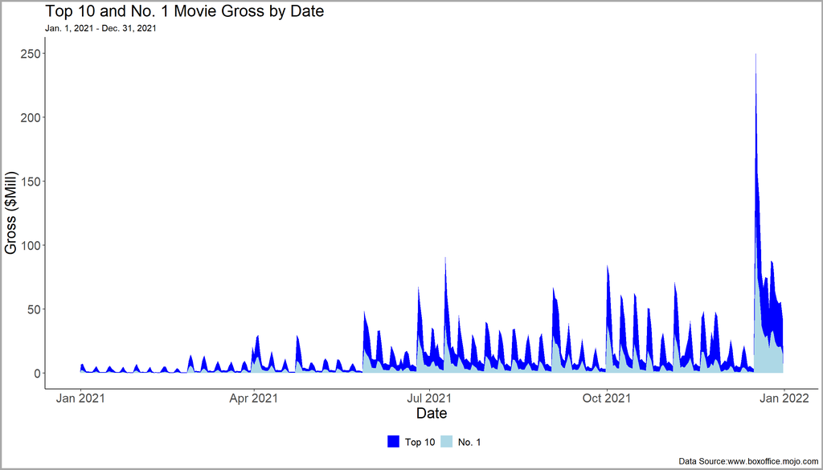

```r
area_plt21_orig <- bom21_line_area |>
  ggplot() +
  geom_area(aes(x=date, y=grossM, fill=type), size=1) +
  theme_classic() +
  scale_fill_manual(values=c("blue", "lightblue")) +
  labs(x="Date", y = "Gross ($Mill)", fill="",
       title="Top 10 and No. 1 Movie Gross by Date",
       subtitle="Jan. 1, 2021 - Dec. 31, 2021",
       caption="Data Source:www.boxoffice.mojo.com") +
  theme(legend.position="bottom",
        legend.text = element_text(size = 12),
        plot.title = element_text(size = 20),
        axis.title = element_text(size=18),
        axis.text = element_text(size=15),
        plot.caption = element_text(size = 10),
        plot.background = element_rect(colour = "darkgrey", fill=NA, size=2))
```

### Area Plot Function

```r
area_plt<- function(data_in, yr){
  data_in |>
  ggplot() +
  geom_area(aes(x=date, y=grossM, fill=type), size=1) +
  theme_classic() +
  scale_fill_manual(values=c("blue", "lightblue")) +
  labs(x="Date", y = "Gross ($Mill)", fill="",
       title="Top 10 and No. 1 Movie Gross by Date",
       subtitle=paste("Jan. 1,", yr,"- Dec. 31,", yr),
       caption="Data Source:www.boxoffice.mojo.com") +
  theme(legend.position="bottom",
        legend.text = element_text(size = 12),
        plot.title = element_text(size = 20),
        axis.title = element_text(size=18),
        axis.text = element_text(size=15),
        plot.caption = element_text(size = 10),
        plot.background = element_rect(colour = "darkgrey", fill=NA, size=2))
}
```

### Line Plot Function

- almost identical to Area Plot Function

```r
line_plt<- function(data_in, yr){
  data_in |>
  ggplot() +
  geom_line(aes(x=date, y=grossM, color=type), size=1) +
  theme_classic() +
  scale_color_manual(values=c("blue", "lightblue")) +
  labs(x="Date", y = "Gross ($Mill)", color="",
       title="Top 10 and No. 1 Movie Gross by Date",
       subtitle=paste("Jan. 1,", yr,"- Dec. 31,", yr),
       caption="Data Source:www.boxoffice.mojo.com") +
  theme(legend.position="bottom",
        legend.text = element_text(size = 12),
        plot.title = element_text(size = 20),
        axis.title = element_text(size=18),
        axis.text = element_text(size=15),
        plot.caption = element_text(size = 10),
        plot.background = element_rect(colour = "darkgrey", fill=NA, size=2))
}
```

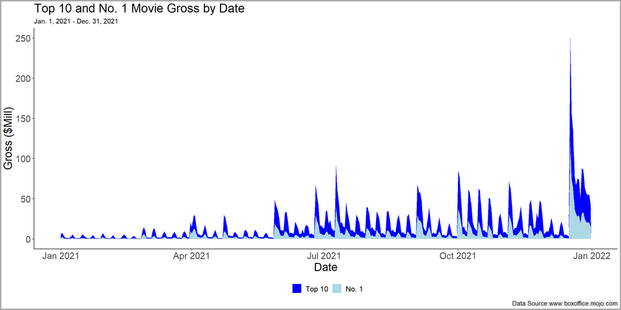

```r
bom21_line_area <- bom_line_area(bom21)
area_plt(bom21_line_area, "2021")
```

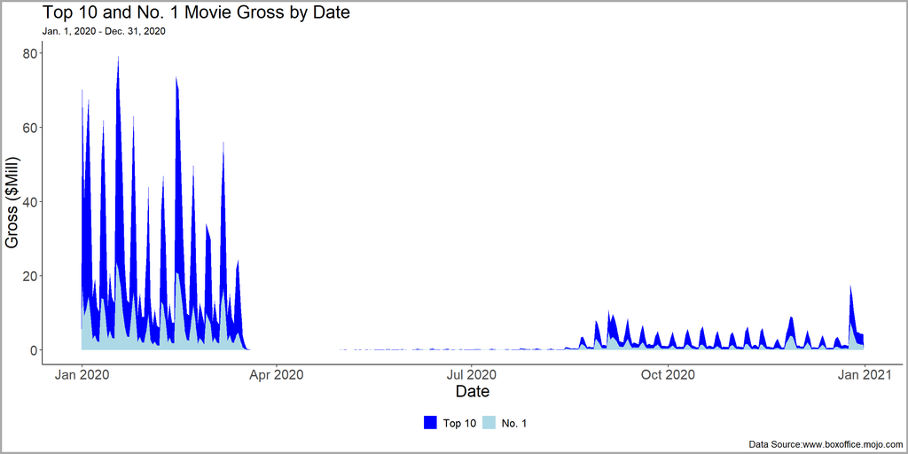

```r
bom21_line_area <- bom_line_area(bom20)
area_plt(bom21_line_area, "2020")
```

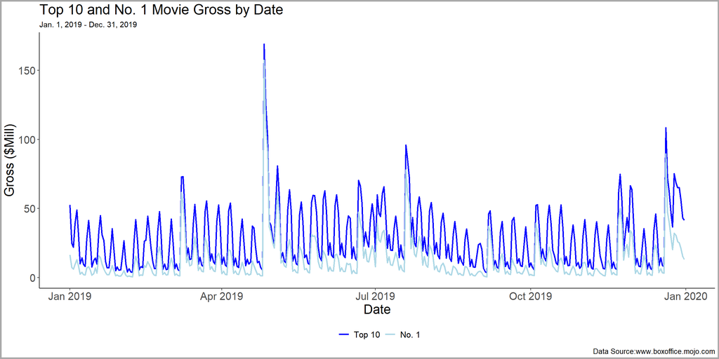

```r
bom19_line_area <- bom_line_area(bom19)
line_plt(bom19_line_area, "2019")
```

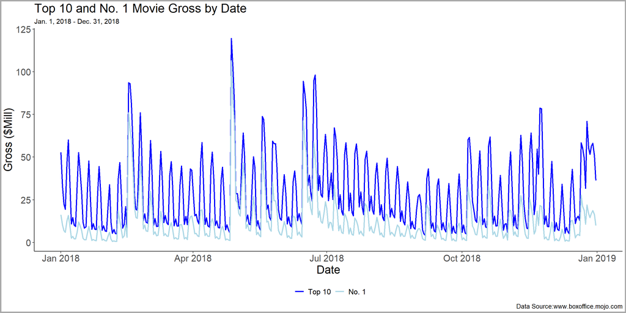

```r
bom18_line_area <- bom_line_area(bom18)
line_plt(bom18_line_area, "2018")
```

### Preview of Next week

- Cleaning Messy Data from Box Office Mojo Website
- Examining/Cleaning Bureau of Labor Statistics data
- Writing functions to automate data cleaning
- Joining data from multiple datasets
- HW 4 will be assigned

### **Key Points from Week 5**

**Review for Quiz 1**

- Review Practice Questions
- Drop into Office Hours if you have additional questions.

**Automating Data Management and Plots with Functions**

- Anatomy of a Function is always consistent
- Functions are useful for repetitive tasks e.g. Same data source, but multiple years
- Divide task into smaller tasks and create a function for each task
- Fully develop and check code to complete tasks, then convert to function.

You may submit an ‘Engagement Question’ about each lecture until midnight on the day of the lecture. **A minimum of four submissions are required during the semester.**